# SynopsysProject

### Name: Ananya Kotla, Christina Ong, Audrey Yin

### 2026 Synopsys Championship Project

#### Project Title: AI-Based Software Application for Detection and Grading of Breast Cancer from Analyzing Fine-Needle Aspirate Data

#### Dataset Link: https://www.kaggle.com/datasets/uciml/breast-cancer-wisconsin-data?resource=download

#### Description of Dataset:

The Breast Cancer Wisconsin (Diagnostic) Data Set is used to predict whether a tumor is malignant (cancerous) or benign (non-cancerous) based on features that describe characteristics of the cell nuclei. These features, included in the data set, are computed from a digitized image of a fine needle aspirate (FNA) of a breast mass.

**Number of Instances:** 569

**Variables:**

- id (ID): ID number
- diagnosis (TARGET): The diagnosis of breast tissues (M = malignant, B = benign)
- radius_mean: The mean of distances from center to points on the perimeter
- texture_mean: The standard deviation of gray-scale values
- perimeter_mean: The mean size of the core tumor
- area_mean: The average area of the nucleus
- smoothness_mean: The mean of local variation in radius lengths
- compactness_mean: The mean of perimeter^2 / area - 1.0 of the nucleus shape
- concavity_mean: The mean of severity of concave portions of the contour
- concave points_mean: The mean for number of concave portions of the contour
- symmetry_mean: The mean for symmetry of the nucleus shape
- fractal_dimension_mean: The mean for "coastline approximation" - 1
- radius_se: Standard error of radius_mean
- texture_se: Standard error of the texture_mean
- perimeter_se: Standard error of the perimeter_mean
- area_se: Standard error of the area_mean
- smoothness_se: Standard error of the smoothness_mean
- compactness_se: Standard error of the compactness_mean
- concavity_se: Standard error of the concavity_mean
- concave points_se: Standard error of the concave points_mean
- symmetry_se: Standard error of the symmetry_mean
- fractal_dimension_se: Standard error of the fractal_dimension_mean
- radius_worst: "Worst" or largest mean value for the radius_mean
- texture_worst — "Worst" or largest mean value for the texture_mean
- perimeter_worst — "Worst" or largest mean value for the perimeter_mean
- area_worst — "Worst" or largest mean value for the area_mean
- smoothness_worst — "Worst" or largest mean value for the smoothness_mean
- compactness_worst — "Worst" or largest mean value for the compactness_mean
- concavity_worst — "Worst" or largest mean value for the concavity_mean
- concave points_worst — "Worst" or largest mean value for the concave points_mean
- symmetry_worst — "Worst" or largest mean value for the symmetry_mean
- fractal_dimension_worst — "Worst" or largest mean value for thefractal_dimension_mean

```python
# Import libraries
import pandas as pd
import numpy as np
import matplotlib.pyplot as plt
%matplotlib inline
import scipy.stats as stats
from scipy.stats import skew, norm, probplot
from matplotlib.pyplot import boxplot
import seaborn as sns
import warnings
warnings.filterwarnings("ignore")
```

```python
# Import
df = pd.read_csv("data.csv")
```

```python
df.info()
```

```
<class 'pandas.core.frame.DataFrame'>
RangeIndex: 569 entries, 0 to 568
Data columns (total 33 columns):
 #   Column                   Non-Null Count  Dtype
---  ------                   --------------  -----
 0   id                       569 non-null    int64
 1   diagnosis                569 non-null    object
 2   radius_mean              569 non-null    float64
 3   texture_mean             569 non-null    float64
 4   perimeter_mean           569 non-null    float64
 5   area_mean                569 non-null    float64
 6   smoothness_mean          569 non-null    float64
 7   compactness_mean         569 non-null    float64
 8   concavity_mean           569 non-null    float64
 9   concave points_mean      569 non-null    float64
```

[output cut: 25 more lines]

## Data Cleaning

```python
# Cleaning Data
# Removed 2 columns, an empty one and an id column, because it doesn't affect the diagnosis variable
del df['Unnamed: 32']
del df['id']
```

```python
df.info()
```

```
<class 'pandas.core.frame.DataFrame'>
RangeIndex: 569 entries, 0 to 568
Data columns (total 31 columns):
 #   Column                   Non-Null Count  Dtype
---  ------                   --------------  -----
 0   diagnosis                569 non-null    object
 1   radius_mean              569 non-null    float64
 2   texture_mean             569 non-null    float64
 3   perimeter_mean           569 non-null    float64
 4   area_mean                569 non-null    float64
 5   smoothness_mean          569 non-null    float64
 6   compactness_mean         569 non-null    float64
 7   concavity_mean           569 non-null    float64
 8   concave points_mean      569 non-null    float64
 9   symmetry_mean            569 non-null    float64
```

[output cut: 23 more lines]

```python
# Convert 'diagnosis' (TARGET) column: M → 1, B → 0
# It will be easier to use for models
df['diagnosis'] = df['diagnosis'].map({'M': 1, 'B': 0})
```

```python
df.info()
```

```
<class 'pandas.core.frame.DataFrame'>
RangeIndex: 569 entries, 0 to 568
Data columns (total 31 columns):
 #   Column                   Non-Null Count  Dtype
---  ------                   --------------  -----
 0   diagnosis                569 non-null    int64
 1   radius_mean              569 non-null    float64
 2   texture_mean             569 non-null    float64
 3   perimeter_mean           569 non-null    float64
 4   area_mean                569 non-null    float64
 5   smoothness_mean          569 non-null    float64
 6   compactness_mean         569 non-null    float64
 7   concavity_mean           569 non-null    float64
 8   concave points_mean      569 non-null    float64
 9   symmetry_mean            569 non-null    float64
```

[output cut: 23 more lines]

```python
df.head()
```

|  | diagnosis | radius_mean | texture_mean | perimeter_mean | area_mean | smoothness_mean | compactness_mean | concavity_mean | concave points_mean | symmetry_mean | ... | radius_worst | texture_worst | perimeter_worst | area_worst | smoothness_worst | compactness_worst | concavity_worst | concave points_worst | symmetry_worst | fractal_dimension_worst |
| --- | --- | --- | --- | --- | --- | --- | --- | --- | --- | --- | --- | --- | --- | --- | --- | --- | --- | --- | --- | --- | --- |
| 0 | 1 | 17.99 | 10.38 | 122.80 | 1001.0 | 0.11840 | 0.27760 | 0.3001 | 0.14710 | 0.2419 | ... | 25.38 | 17.33 | 184.60 | 2019.0 | 0.1622 | 0.6656 | 0.7119 | 0.2654 | 0.4601 | 0.11890 |
| 1 | 1 | 20.57 | 17.77 | 132.90 | 1326.0 | 0.08474 | 0.07864 | 0.0869 | 0.07017 | 0.1812 | ... | 24.99 | 23.41 | 158.80 | 1956.0 | 0.1238 | 0.1866 | 0.2416 | 0.1860 | 0.2750 | 0.08902 |
| 2 | 1 | 19.69 | 21.25 | 130.00 | 1203.0 | 0.10960 | 0.15990 | 0.1974 | 0.12790 | 0.2069 | ... | 23.57 | 25.53 | 152.50 | 1709.0 | 0.1444 | 0.4245 | 0.4504 | 0.2430 | 0.3613 | 0.08758 |
| 3 | 1 | 11.42 | 20.38 | 77.58 | 386.1 | 0.14250 | 0.28390 | 0.2414 | 0.10520 | 0.2597 | ... | 14.91 | 26.50 | 98.87 | 567.7 | 0.2098 | 0.8663 | 0.6869 | 0.2575 | 0.6638 | 0.17300 |
| 4 | 1 | 20.29 | 14.34 | 135.10 | 1297.0 | 0.10030 | 0.13280 | 0.1980 | 0.10430 | 0.1809 | ... | 22.54 | 16.67 | 152.20 | 1575.0 | 0.1374 | 0.2050 | 0.4000 | 0.1625 | 0.2364 | 0.07678 |

5 rows × 31 columns

```python
df.tail()
```

|  | diagnosis | radius_mean | texture_mean | perimeter_mean | area_mean | smoothness_mean | compactness_mean | concavity_mean | concave points_mean | symmetry_mean | ... | radius_worst | texture_worst | perimeter_worst | area_worst | smoothness_worst | compactness_worst | concavity_worst | concave points_worst | symmetry_worst | fractal_dimension_worst |
| --- | --- | --- | --- | --- | --- | --- | --- | --- | --- | --- | --- | --- | --- | --- | --- | --- | --- | --- | --- | --- | --- |
| 564 | 1 | 21.56 | 22.39 | 142.00 | 1479.0 | 0.11100 | 0.11590 | 0.24390 | 0.13890 | 0.1726 | ... | 25.450 | 26.40 | 166.10 | 2027.0 | 0.14100 | 0.21130 | 0.4107 | 0.2216 | 0.2060 | 0.07115 |
| 565 | 1 | 20.13 | 28.25 | 131.20 | 1261.0 | 0.09780 | 0.10340 | 0.14400 | 0.09791 | 0.1752 | ... | 23.690 | 38.25 | 155.00 | 1731.0 | 0.11660 | 0.19220 | 0.3215 | 0.1628 | 0.2572 | 0.06637 |
| 566 | 1 | 16.60 | 28.08 | 108.30 | 858.1 | 0.08455 | 0.10230 | 0.09251 | 0.05302 | 0.1590 | ... | 18.980 | 34.12 | 126.70 | 1124.0 | 0.11390 | 0.30940 | 0.3403 | 0.1418 | 0.2218 | 0.07820 |
| 567 | 1 | 20.60 | 29.33 | 140.10 | 1265.0 | 0.11780 | 0.27700 | 0.35140 | 0.15200 | 0.2397 | ... | 25.740 | 39.42 | 184.60 | 1821.0 | 0.16500 | 0.86810 | 0.9387 | 0.2650 | 0.4087 | 0.12400 |
| 568 | 0 | 7.76 | 24.54 | 47.92 | 181.0 | 0.05263 | 0.04362 | 0.00000 | 0.00000 | 0.1587 | ... | 9.456 | 30.37 | 59.16 | 268.6 | 0.08996 | 0.06444 | 0.0000 | 0.0000 | 0.2871 | 0.07039 |

5 rows × 31 columns

## Descriptive Statistcs

```python
# Calculated to gain insights intro data distribution
df.mean()
```

```
diagnosis                    0.372583
radius_mean                 14.127292
texture_mean                19.289649
perimeter_mean              91.969033
area_mean                  654.889104
smoothness_mean              0.096360
compactness_mean             0.104341
concavity_mean               0.088799
concave points_mean          0.048919
symmetry_mean                0.181162
fractal_dimension_mean       0.062798
radius_se                    0.405172
texture_se                   1.216853
perimeter_se                 2.866059
area_se                     40.337079
smoothness_se                0.007041
compactness_se               0.025478
concavity_se                 0.031894
concave points_se            0.011796
symmetry_se                  0.020542
fractal_dimension_se         0.003795
radius_worst                16.269190
texture_worst               25.677223
perimeter_worst            107.261213
area_worst                 880.583128
smoothness_worst             0.132369
compactness_worst            0.254265
concavity_worst              0.272188
concave points_worst         0.114606
symmetry_worst               0.290076
fractal_dimension_worst      0.083946
dtype: float64
```

```python
df.median()
```

```
diagnosis                    0.000000
radius_mean                 13.370000
texture_mean                18.840000
perimeter_mean              86.240000
area_mean                  551.100000
smoothness_mean              0.095870
compactness_mean             0.092630
concavity_mean               0.061540
concave points_mean          0.033500
symmetry_mean                0.179200
fractal_dimension_mean       0.061540
radius_se                    0.324200
texture_se                   1.108000
perimeter_se                 2.287000
area_se                     24.530000
smoothness_se                0.006380
compactness_se               0.020450
concavity_se                 0.025890
concave points_se            0.010930
symmetry_se                  0.018730
fractal_dimension_se         0.003187
radius_worst                14.970000
texture_worst               25.410000
perimeter_worst             97.660000
area_worst                 686.500000
smoothness_worst             0.131300
compactness_worst            0.211900
concavity_worst              0.226700
concave points_worst         0.099930
symmetry_worst               0.282200
fractal_dimension_worst      0.080040
dtype: float64
```

```python
df.mode()
```

|  | diagnosis | radius_mean | texture_mean | perimeter_mean | area_mean | smoothness_mean | compactness_mean | concavity_mean | concave points_mean | symmetry_mean | ... | radius_worst | texture_worst | perimeter_worst | area_worst | smoothness_worst | compactness_worst | concavity_worst | concave points_worst | symmetry_worst | fractal_dimension_worst |
| --- | --- | --- | --- | --- | --- | --- | --- | --- | --- | --- | --- | --- | --- | --- | --- | --- | --- | --- | --- | --- | --- |
| 0 | 0.0 | 12.34 | 14.93 | 82.61 | 512.2 | 0.1007 | 0.1147 | 0.0 | 0.0 | 0.1601 | ... | 12.36 | 17.70 | 101.7 | 284.4 | 0.1216 | 0.1486 | 0.0 | 0.0 | 0.2226 | 0.07427 |
| 1 | NaN | NaN | 15.70 | 87.76 | NaN | NaN | 0.1206 | NaN | NaN | 0.1714 | ... | NaN | 27.26 | 105.9 | 402.8 | 0.1223 | 0.3416 | NaN | NaN | 0.2369 | NaN |
| 2 | NaN | NaN | 16.84 | 134.70 | NaN | NaN | NaN | NaN | NaN | 0.1717 | ... | NaN | NaN | 117.7 | 439.6 | 0.1234 | NaN | NaN | NaN | 0.2383 | NaN |
| 3 | NaN | NaN | 16.85 | NaN | NaN | NaN | NaN | NaN | NaN | 0.1769 | ... | NaN | NaN | NaN | 458.0 | 0.1256 | NaN | NaN | NaN | 0.2972 | NaN |
| 4 | NaN | NaN | 17.46 | NaN | NaN | NaN | NaN | NaN | NaN | 0.1893 | ... | NaN | NaN | NaN | 472.4 | 0.1275 | NaN | NaN | NaN | 0.3109 | NaN |
| 5 | NaN | NaN | 18.22 | NaN | NaN | NaN | NaN | NaN | NaN | NaN | ... | NaN | NaN | NaN | 489.5 | 0.1312 | NaN | NaN | NaN | 0.3196 | NaN |
| 6 | NaN | NaN | 18.90 | NaN | NaN | NaN | NaN | NaN | NaN | NaN | ... | NaN | NaN | NaN | 546.7 | 0.1347 | NaN | NaN | NaN | NaN | NaN |
| 7 | NaN | NaN | 19.83 | NaN | NaN | NaN | NaN | NaN | NaN | NaN | ... | NaN | NaN | NaN | 547.4 | 0.1401 | NaN | NaN | NaN | NaN | NaN |
| 8 | NaN | NaN | 20.52 | NaN | NaN | NaN | NaN | NaN | NaN | NaN | ... | NaN | NaN | NaN | 624.1 | 0.1415 | NaN | NaN | NaN | NaN | NaN |
| 9 | NaN | NaN | NaN | NaN | NaN | NaN | NaN | NaN | NaN | NaN | ... | NaN | NaN | NaN | 698.8 | NaN | NaN | NaN | NaN | NaN | NaN |
| 10 | NaN | NaN | NaN | NaN | NaN | NaN | NaN | NaN | NaN | NaN | ... | NaN | NaN | NaN | 706.0 | NaN | NaN | NaN | NaN | NaN | NaN |
| 11 | NaN | NaN | NaN | NaN | NaN | NaN | NaN | NaN | NaN | NaN | ... | NaN | NaN | NaN | 708.8 | NaN | NaN | NaN | NaN | NaN | NaN |
| 12 | NaN | NaN | NaN | NaN | NaN | NaN | NaN | NaN | NaN | NaN | ... | NaN | NaN | NaN | 725.9 | NaN | NaN | NaN | NaN | NaN | NaN |
| 13 | NaN | NaN | NaN | NaN | NaN | NaN | NaN | NaN | NaN | NaN | ... | NaN | NaN | NaN | 733.5 | NaN | NaN | NaN | NaN | NaN | NaN |
| 14 | NaN | NaN | NaN | NaN | NaN | NaN | NaN | NaN | NaN | NaN | ... | NaN | NaN | NaN | 749.9 | NaN | NaN | NaN | NaN | NaN | NaN |
| 15 | NaN | NaN | NaN | NaN | NaN | NaN | NaN | NaN | NaN | NaN | ... | NaN | NaN | NaN | 808.9 | NaN | NaN | NaN | NaN | NaN | NaN |
| 16 | NaN | NaN | NaN | NaN | NaN | NaN | NaN | NaN | NaN | NaN | ... | NaN | NaN | NaN | 826.4 | NaN | NaN | NaN | NaN | NaN | NaN |
| 17 | NaN | NaN | NaN | NaN | NaN | NaN | NaN | NaN | NaN | NaN | ... | NaN | NaN | NaN | 830.5 | NaN | NaN | NaN | NaN | NaN | NaN |
| 18 | NaN | NaN | NaN | NaN | NaN | NaN | NaN | NaN | NaN | NaN | ... | NaN | NaN | NaN | 1210.0 | NaN | NaN | NaN | NaN | NaN | NaN |
| 19 | NaN | NaN | NaN | NaN | NaN | NaN | NaN | NaN | NaN | NaN | ... | NaN | NaN | NaN | 1261.0 | NaN | NaN | NaN | NaN | NaN | NaN |
| 20 | NaN | NaN | NaN | NaN | NaN | NaN | NaN | NaN | NaN | NaN | ... | NaN | NaN | NaN | 1269.0 | NaN | NaN | NaN | NaN | NaN | NaN |
| 21 | NaN | NaN | NaN | NaN | NaN | NaN | NaN | NaN | NaN | NaN | ... | NaN | NaN | NaN | 1437.0 | NaN | NaN | NaN | NaN | NaN | NaN |
| 22 | NaN | NaN | NaN | NaN | NaN | NaN | NaN | NaN | NaN | NaN | ... | NaN | NaN | NaN | 1603.0 | NaN | NaN | NaN | NaN | NaN | NaN |
| 23 | NaN | NaN | NaN | NaN | NaN | NaN | NaN | NaN | NaN | NaN | ... | NaN | NaN | NaN | 1623.0 | NaN | NaN | NaN | NaN | NaN | NaN |
| 24 | NaN | NaN | NaN | NaN | NaN | NaN | NaN | NaN | NaN | NaN | ... | NaN | NaN | NaN | 1750.0 | NaN | NaN | NaN | NaN | NaN | NaN |

25 rows × 31 columns

```python
df.std()
```

```
diagnosis                    0.483918
radius_mean                  3.524049
texture_mean                 4.301036
perimeter_mean              24.298981
area_mean                  351.914129
smoothness_mean              0.014064
compactness_mean             0.052813
concavity_mean               0.079720
concave points_mean          0.038803
symmetry_mean                0.027414
fractal_dimension_mean       0.007060
radius_se                    0.277313
texture_se                   0.551648
perimeter_se                 2.021855
area_se                     45.491006
smoothness_se                0.003003
compactness_se               0.017908
concavity_se                 0.030186
concave points_se            0.006170
symmetry_se                  0.008266
fractal_dimension_se         0.002646
radius_worst                 4.833242
texture_worst                6.146258
perimeter_worst             33.602542
area_worst                 569.356993
smoothness_worst             0.022832
compactness_worst            0.157336
concavity_worst              0.208624
concave points_worst         0.065732
symmetry_worst               0.061867
fractal_dimension_worst      0.018061
dtype: float64
```

```python
df.std()*3
```

```
diagnosis                     1.451754
radius_mean                  10.572146
texture_mean                 12.903107
perimeter_mean               72.896943
area_mean                  1055.742388
smoothness_mean               0.042192
compactness_mean              0.158438
concavity_mean                0.239159
concave points_mean           0.116409
symmetry_mean                 0.082243
fractal_dimension_mean        0.021181
radius_se                     0.831938
texture_se                    1.654945
perimeter_se                  6.065564
area_se                     136.473017
smoothness_se                 0.009008
compactness_se                0.053725
concavity_se                  0.090558
concave points_se             0.018511
symmetry_se                   0.024799
fractal_dimension_se          0.007938
radius_worst                 14.499725
texture_worst                18.438773
perimeter_worst             100.807627
area_worst                 1708.070978
smoothness_worst              0.068497
compactness_worst             0.472009
concavity_worst               0.625873
concave points_worst          0.197197
symmetry_worst                0.185602
fractal_dimension_worst       0.054184
dtype: float64
```

```python
df.columns
```

```
Index(['diagnosis', 'radius_mean', 'texture_mean', 'perimeter_mean',
       'area_mean', 'smoothness_mean', 'compactness_mean', 'concavity_mean',
       'concave points_mean', 'symmetry_mean', 'fractal_dimension_mean',
       'radius_se', 'texture_se', 'perimeter_se', 'area_se', 'smoothness_se',
       'compactness_se', 'concavity_se', 'concave points_se', 'symmetry_se',
       'fractal_dimension_se', 'radius_worst', 'texture_worst',
       'perimeter_worst', 'area_worst', 'smoothness_worst',
       'compactness_worst', 'concavity_worst', 'concave points_worst',
       'symmetry_worst', 'fractal_dimension_worst'],
      dtype='object')
```

```python
# Number of rows, columns
df.shape
```

```
(569, 31)
```

```python
df.describe()
```

|  | diagnosis | radius_mean | texture_mean | perimeter_mean | area_mean | smoothness_mean | compactness_mean | concavity_mean | concave points_mean | symmetry_mean | ... | radius_worst | texture_worst | perimeter_worst | area_worst | smoothness_worst | compactness_worst | concavity_worst | concave points_worst | symmetry_worst | fractal_dimension_worst |
| --- | --- | --- | --- | --- | --- | --- | --- | --- | --- | --- | --- | --- | --- | --- | --- | --- | --- | --- | --- | --- | --- |
| count | 569.000000 | 569.000000 | 569.000000 | 569.000000 | 569.000000 | 569.000000 | 569.000000 | 569.000000 | 569.000000 | 569.000000 | ... | 569.000000 | 569.000000 | 569.000000 | 569.000000 | 569.000000 | 569.000000 | 569.000000 | 569.000000 | 569.000000 | 569.000000 |
| mean | 0.372583 | 14.127292 | 19.289649 | 91.969033 | 654.889104 | 0.096360 | 0.104341 | 0.088799 | 0.048919 | 0.181162 | ... | 16.269190 | 25.677223 | 107.261213 | 880.583128 | 0.132369 | 0.254265 | 0.272188 | 0.114606 | 0.290076 | 0.083946 |
| std | 0.483918 | 3.524049 | 4.301036 | 24.298981 | 351.914129 | 0.014064 | 0.052813 | 0.079720 | 0.038803 | 0.027414 | ... | 4.833242 | 6.146258 | 33.602542 | 569.356993 | 0.022832 | 0.157336 | 0.208624 | 0.065732 | 0.061867 | 0.018061 |
| min | 0.000000 | 6.981000 | 9.710000 | 43.790000 | 143.500000 | 0.052630 | 0.019380 | 0.000000 | 0.000000 | 0.106000 | ... | 7.930000 | 12.020000 | 50.410000 | 185.200000 | 0.071170 | 0.027290 | 0.000000 | 0.000000 | 0.156500 | 0.055040 |
| 25% | 0.000000 | 11.700000 | 16.170000 | 75.170000 | 420.300000 | 0.086370 | 0.064920 | 0.029560 | 0.020310 | 0.161900 | ... | 13.010000 | 21.080000 | 84.110000 | 515.300000 | 0.116600 | 0.147200 | 0.114500 | 0.064930 | 0.250400 | 0.071460 |
| 50% | 0.000000 | 13.370000 | 18.840000 | 86.240000 | 551.100000 | 0.095870 | 0.092630 | 0.061540 | 0.033500 | 0.179200 | ... | 14.970000 | 25.410000 | 97.660000 | 686.500000 | 0.131300 | 0.211900 | 0.226700 | 0.099930 | 0.282200 | 0.080040 |
| 75% | 1.000000 | 15.780000 | 21.800000 | 104.100000 | 782.700000 | 0.105300 | 0.130400 | 0.130700 | 0.074000 | 0.195700 | ... | 18.790000 | 29.720000 | 125.400000 | 1084.000000 | 0.146000 | 0.339100 | 0.382900 | 0.161400 | 0.317900 | 0.092080 |
| max | 1.000000 | 28.110000 | 39.280000 | 188.500000 | 2501.000000 | 0.163400 | 0.345400 | 0.426800 | 0.201200 | 0.304000 | ... | 36.040000 | 49.540000 | 251.200000 | 4254.000000 | 0.222600 | 1.058000 | 1.252000 | 0.291000 | 0.663800 | 0.207500 |

8 rows × 31 columns

```python
df.describe().T
```

|  | count | mean | std | min | 25% | 50% | 75% | max |
| --- | --- | --- | --- | --- | --- | --- | --- | --- |
| diagnosis | 569.0 | 0.372583 | 0.483918 | 0.000000 | 0.000000 | 0.000000 | 1.000000 | 1.00000 |
| radius_mean | 569.0 | 14.127292 | 3.524049 | 6.981000 | 11.700000 | 13.370000 | 15.780000 | 28.11000 |
| texture_mean | 569.0 | 19.289649 | 4.301036 | 9.710000 | 16.170000 | 18.840000 | 21.800000 | 39.28000 |
| perimeter_mean | 569.0 | 91.969033 | 24.298981 | 43.790000 | 75.170000 | 86.240000 | 104.100000 | 188.50000 |
| area_mean | 569.0 | 654.889104 | 351.914129 | 143.500000 | 420.300000 | 551.100000 | 782.700000 | 2501.00000 |
| smoothness_mean | 569.0 | 0.096360 | 0.014064 | 0.052630 | 0.086370 | 0.095870 | 0.105300 | 0.16340 |
| compactness_mean | 569.0 | 0.104341 | 0.052813 | 0.019380 | 0.064920 | 0.092630 | 0.130400 | 0.34540 |
| concavity_mean | 569.0 | 0.088799 | 0.079720 | 0.000000 | 0.029560 | 0.061540 | 0.130700 | 0.42680 |
| concave points_mean | 569.0 | 0.048919 | 0.038803 | 0.000000 | 0.020310 | 0.033500 | 0.074000 | 0.20120 |
| symmetry_mean | 569.0 | 0.181162 | 0.027414 | 0.106000 | 0.161900 | 0.179200 | 0.195700 | 0.30400 |
| fractal_dimension_mean | 569.0 | 0.062798 | 0.007060 | 0.049960 | 0.057700 | 0.061540 | 0.066120 | 0.09744 |
| radius_se | 569.0 | 0.405172 | 0.277313 | 0.111500 | 0.232400 | 0.324200 | 0.478900 | 2.87300 |
| texture_se | 569.0 | 1.216853 | 0.551648 | 0.360200 | 0.833900 | 1.108000 | 1.474000 | 4.88500 |
| perimeter_se | 569.0 | 2.866059 | 2.021855 | 0.757000 | 1.606000 | 2.287000 | 3.357000 | 21.98000 |
| area_se | 569.0 | 40.337079 | 45.491006 | 6.802000 | 17.850000 | 24.530000 | 45.190000 | 542.20000 |
| smoothness_se | 569.0 | 0.007041 | 0.003003 | 0.001713 | 0.005169 | 0.006380 | 0.008146 | 0.03113 |
| compactness_se | 569.0 | 0.025478 | 0.017908 | 0.002252 | 0.013080 | 0.020450 | 0.032450 | 0.13540 |
| concavity_se | 569.0 | 0.031894 | 0.030186 | 0.000000 | 0.015090 | 0.025890 | 0.042050 | 0.39600 |
| concave points_se | 569.0 | 0.011796 | 0.006170 | 0.000000 | 0.007638 | 0.010930 | 0.014710 | 0.05279 |
| symmetry_se | 569.0 | 0.020542 | 0.008266 | 0.007882 | 0.015160 | 0.018730 | 0.023480 | 0.07895 |
| fractal_dimension_se | 569.0 | 0.003795 | 0.002646 | 0.000895 | 0.002248 | 0.003187 | 0.004558 | 0.02984 |
| radius_worst | 569.0 | 16.269190 | 4.833242 | 7.930000 | 13.010000 | 14.970000 | 18.790000 | 36.04000 |
| texture_worst | 569.0 | 25.677223 | 6.146258 | 12.020000 | 21.080000 | 25.410000 | 29.720000 | 49.54000 |
| perimeter_worst | 569.0 | 107.261213 | 33.602542 | 50.410000 | 84.110000 | 97.660000 | 125.400000 | 251.20000 |
| area_worst | 569.0 | 880.583128 | 569.356993 | 185.200000 | 515.300000 | 686.500000 | 1084.000000 | 4254.00000 |
| smoothness_worst | 569.0 | 0.132369 | 0.022832 | 0.071170 | 0.116600 | 0.131300 | 0.146000 | 0.22260 |
| compactness_worst | 569.0 | 0.254265 | 0.157336 | 0.027290 | 0.147200 | 0.211900 | 0.339100 | 1.05800 |
| concavity_worst | 569.0 | 0.272188 | 0.208624 | 0.000000 | 0.114500 | 0.226700 | 0.382900 | 1.25200 |
| concave points_worst | 569.0 | 0.114606 | 0.065732 | 0.000000 | 0.064930 | 0.099930 | 0.161400 | 0.29100 |
| symmetry_worst | 569.0 | 0.290076 | 0.061867 | 0.156500 | 0.250400 | 0.282200 | 0.317900 | 0.66380 |
| fractal_dimension_worst | 569.0 | 0.083946 | 0.018061 | 0.055040 | 0.071460 | 0.080040 | 0.092080 | 0.20750 |

```python
# Reduce number of decimals
pd.set_option('display.float_format', lambda x: '%.2f' % x)
df.describe().T
```

|  | count | mean | std | min | 25% | 50% | 75% | max |
| --- | --- | --- | --- | --- | --- | --- | --- | --- |
| diagnosis | 569.00 | 0.37 | 0.48 | 0.00 | 0.00 | 0.00 | 1.00 | 1.00 |
| radius_mean | 569.00 | 14.13 | 3.52 | 6.98 | 11.70 | 13.37 | 15.78 | 28.11 |
| texture_mean | 569.00 | 19.29 | 4.30 | 9.71 | 16.17 | 18.84 | 21.80 | 39.28 |
| perimeter_mean | 569.00 | 91.97 | 24.30 | 43.79 | 75.17 | 86.24 | 104.10 | 188.50 |
| area_mean | 569.00 | 654.89 | 351.91 | 143.50 | 420.30 | 551.10 | 782.70 | 2501.00 |
| smoothness_mean | 569.00 | 0.10 | 0.01 | 0.05 | 0.09 | 0.10 | 0.11 | 0.16 |
| compactness_mean | 569.00 | 0.10 | 0.05 | 0.02 | 0.06 | 0.09 | 0.13 | 0.35 |
| concavity_mean | 569.00 | 0.09 | 0.08 | 0.00 | 0.03 | 0.06 | 0.13 | 0.43 |
| concave points_mean | 569.00 | 0.05 | 0.04 | 0.00 | 0.02 | 0.03 | 0.07 | 0.20 |
| symmetry_mean | 569.00 | 0.18 | 0.03 | 0.11 | 0.16 | 0.18 | 0.20 | 0.30 |
| fractal_dimension_mean | 569.00 | 0.06 | 0.01 | 0.05 | 0.06 | 0.06 | 0.07 | 0.10 |
| radius_se | 569.00 | 0.41 | 0.28 | 0.11 | 0.23 | 0.32 | 0.48 | 2.87 |
| texture_se | 569.00 | 1.22 | 0.55 | 0.36 | 0.83 | 1.11 | 1.47 | 4.88 |
| perimeter_se | 569.00 | 2.87 | 2.02 | 0.76 | 1.61 | 2.29 | 3.36 | 21.98 |
| area_se | 569.00 | 40.34 | 45.49 | 6.80 | 17.85 | 24.53 | 45.19 | 542.20 |
| smoothness_se | 569.00 | 0.01 | 0.00 | 0.00 | 0.01 | 0.01 | 0.01 | 0.03 |
| compactness_se | 569.00 | 0.03 | 0.02 | 0.00 | 0.01 | 0.02 | 0.03 | 0.14 |
| concavity_se | 569.00 | 0.03 | 0.03 | 0.00 | 0.02 | 0.03 | 0.04 | 0.40 |
| concave points_se | 569.00 | 0.01 | 0.01 | 0.00 | 0.01 | 0.01 | 0.01 | 0.05 |
| symmetry_se | 569.00 | 0.02 | 0.01 | 0.01 | 0.02 | 0.02 | 0.02 | 0.08 |
| fractal_dimension_se | 569.00 | 0.00 | 0.00 | 0.00 | 0.00 | 0.00 | 0.00 | 0.03 |
| radius_worst | 569.00 | 16.27 | 4.83 | 7.93 | 13.01 | 14.97 | 18.79 | 36.04 |
| texture_worst | 569.00 | 25.68 | 6.15 | 12.02 | 21.08 | 25.41 | 29.72 | 49.54 |
| perimeter_worst | 569.00 | 107.26 | 33.60 | 50.41 | 84.11 | 97.66 | 125.40 | 251.20 |
| area_worst | 569.00 | 880.58 | 569.36 | 185.20 | 515.30 | 686.50 | 1084.00 | 4254.00 |
| smoothness_worst | 569.00 | 0.13 | 0.02 | 0.07 | 0.12 | 0.13 | 0.15 | 0.22 |
| compactness_worst | 569.00 | 0.25 | 0.16 | 0.03 | 0.15 | 0.21 | 0.34 | 1.06 |
| concavity_worst | 569.00 | 0.27 | 0.21 | 0.00 | 0.11 | 0.23 | 0.38 | 1.25 |
| concave points_worst | 569.00 | 0.11 | 0.07 | 0.00 | 0.06 | 0.10 | 0.16 | 0.29 |
| symmetry_worst | 569.00 | 0.29 | 0.06 | 0.16 | 0.25 | 0.28 | 0.32 | 0.66 |
| fractal_dimension_worst | 569.00 | 0.08 | 0.02 | 0.06 | 0.07 | 0.08 | 0.09 | 0.21 |

```python
df.diagnosis.value_counts()
```

```
diagnosis
0    357
1    212
Name: count, dtype: int64
```

```python
df["diagnosis"].value_counts()
```

```
diagnosis
0    357
1    212
Name: count, dtype: int64
```

```python
# A random set of 15 rows from the DataFrame will be displayed.
np.random.seed()
df.sample(n=15)
```

|  | diagnosis | radius_mean | texture_mean | perimeter_mean | area_mean | smoothness_mean | compactness_mean | concavity_mean | concave points_mean | symmetry_mean | ... | radius_worst | texture_worst | perimeter_worst | area_worst | smoothness_worst | compactness_worst | concavity_worst | concave points_worst | symmetry_worst | fractal_dimension_worst |
| --- | --- | --- | --- | --- | --- | --- | --- | --- | --- | --- | --- | --- | --- | --- | --- | --- | --- | --- | --- | --- | --- |
| 468 | 1 | 17.60 | 23.33 | 119.00 | 980.50 | 0.09 | 0.20 | 0.21 | 0.10 | 0.17 | ... | 21.57 | 28.87 | 143.60 | 1437.00 | 0.12 | 0.48 | 0.52 | 0.20 | 0.23 | 0.12 |
| 298 | 0 | 14.26 | 18.17 | 91.22 | 633.10 | 0.07 | 0.05 | 0.02 | 0.01 | 0.16 | ... | 16.22 | 25.26 | 105.80 | 819.70 | 0.09 | 0.22 | 0.16 | 0.08 | 0.26 | 0.08 |
| 239 | 1 | 17.46 | 39.28 | 113.40 | 920.60 | 0.10 | 0.13 | 0.14 | 0.09 | 0.18 | ... | 22.51 | 44.87 | 141.20 | 1408.00 | 0.14 | 0.37 | 0.32 | 0.21 | 0.29 | 0.08 |
| 341 | 0 | 9.61 | 16.84 | 61.64 | 280.50 | 0.08 | 0.09 | 0.08 | 0.02 | 0.20 | ... | 10.75 | 23.07 | 71.25 | 353.60 | 0.12 | 0.34 | 0.43 | 0.08 | 0.30 | 0.10 |
| 200 | 0 | 12.23 | 19.56 | 78.54 | 461.00 | 0.10 | 0.08 | 0.04 | 0.04 | 0.20 | ... | 14.44 | 28.36 | 92.15 | 638.40 | 0.14 | 0.20 | 0.14 | 0.11 | 0.27 | 0.08 |
| 530 | 0 | 11.75 | 17.56 | 75.89 | 422.90 | 0.11 | 0.10 | 0.05 | 0.04 | 0.16 | ... | 13.50 | 27.98 | 88.52 | 552.30 | 0.13 | 0.19 | 0.14 | 0.10 | 0.25 | 0.08 |
| 54 | 1 | 15.10 | 22.02 | 97.26 | 712.80 | 0.09 | 0.07 | 0.05 | 0.03 | 0.16 | ... | 18.10 | 31.69 | 117.70 | 1030.00 | 0.14 | 0.21 | 0.27 | 0.15 | 0.27 | 0.08 |
| 177 | 1 | 16.46 | 20.11 | 109.30 | 832.90 | 0.10 | 0.16 | 0.18 | 0.09 | 0.18 | ... | 17.79 | 28.45 | 123.50 | 981.20 | 0.14 | 0.47 | 0.59 | 0.20 | 0.31 | 0.10 |
| 564 | 1 | 21.56 | 22.39 | 142.00 | 1479.00 | 0.11 | 0.12 | 0.24 | 0.14 | 0.17 | ... | 25.45 | 26.40 | 166.10 | 2027.00 | 0.14 | 0.21 | 0.41 | 0.22 | 0.21 | 0.07 |
| 199 | 1 | 14.45 | 20.22 | 94.49 | 642.70 | 0.10 | 0.12 | 0.12 | 0.06 | 0.20 | ... | 18.33 | 30.12 | 117.90 | 1044.00 | 0.16 | 0.41 | 0.50 | 0.18 | 0.48 | 0.10 |
| 475 | 0 | 12.83 | 15.73 | 82.89 | 506.90 | 0.09 | 0.08 | 0.06 | 0.03 | 0.17 | ... | 14.09 | 19.35 | 93.22 | 605.80 | 0.13 | 0.26 | 0.35 | 0.10 | 0.30 | 0.08 |
| 94 | 1 | 15.06 | 19.83 | 100.30 | 705.60 | 0.10 | 0.16 | 0.17 | 0.09 | 0.19 | ... | 18.23 | 24.23 | 123.50 | 1025.00 | 0.16 | 0.42 | 0.52 | 0.21 | 0.28 | 0.08 |
| 462 | 0 | 14.40 | 26.99 | 92.25 | 646.10 | 0.07 | 0.05 | 0.03 | 0.02 | 0.17 | ... | 15.40 | 31.98 | 100.40 | 734.60 | 0.10 | 0.15 | 0.15 | 0.06 | 0.23 | 0.06 |
| 494 | 0 | 13.16 | 20.54 | 84.06 | 538.70 | 0.07 | 0.05 | 0.02 | 0.01 | 0.17 | ... | 14.50 | 28.46 | 95.29 | 648.30 | 0.11 | 0.16 | 0.08 | 0.04 | 0.27 | 0.07 |
| 168 | 1 | 17.47 | 24.68 | 116.10 | 984.60 | 0.10 | 0.16 | 0.22 | 0.10 | 0.15 | ... | 23.14 | 32.33 | 155.30 | 1660.00 | 0.14 | 0.38 | 0.49 | 0.17 | 0.22 | 0.09 |

15 rows × 31 columns

```python
# Checking for duplicated data
df[df.duplicated()].count()
```

```
diagnosis                  0
radius_mean                0
texture_mean               0
perimeter_mean             0
area_mean                  0
smoothness_mean            0
compactness_mean           0
concavity_mean             0
concave points_mean        0
symmetry_mean              0
fractal_dimension_mean     0
radius_se                  0
texture_se                 0
perimeter_se               0
area_se                    0
smoothness_se              0
compactness_se             0
concavity_se               0
concave points_se          0
symmetry_se                0
fractal_dimension_se       0
radius_worst               0
texture_worst              0
perimeter_worst            0
area_worst                 0
smoothness_worst           0
compactness_worst          0
concavity_worst            0
concave points_worst       0
symmetry_worst             0
fractal_dimension_worst    0
dtype: int64
```

## Exploratory Data Analysis

```python
# To explore relationships between variables from the data
# Pearson's Correlation
df.corr()
```

|  | diagnosis | radius_mean | texture_mean | perimeter_mean | area_mean | smoothness_mean | compactness_mean | concavity_mean | concave points_mean | symmetry_mean | ... | radius_worst | texture_worst | perimeter_worst | area_worst | smoothness_worst | compactness_worst | concavity_worst | concave points_worst | symmetry_worst | fractal_dimension_worst |
| --- | --- | --- | --- | --- | --- | --- | --- | --- | --- | --- | --- | --- | --- | --- | --- | --- | --- | --- | --- | --- | --- |
| diagnosis | 1.00 | 0.73 | 0.42 | 0.74 | 0.71 | 0.36 | 0.60 | 0.70 | 0.78 | 0.33 | ... | 0.78 | 0.46 | 0.78 | 0.73 | 0.42 | 0.59 | 0.66 | 0.79 | 0.42 | 0.32 |
| radius_mean | 0.73 | 1.00 | 0.32 | 1.00 | 0.99 | 0.17 | 0.51 | 0.68 | 0.82 | 0.15 | ... | 0.97 | 0.30 | 0.97 | 0.94 | 0.12 | 0.41 | 0.53 | 0.74 | 0.16 | 0.01 |
| texture_mean | 0.42 | 0.32 | 1.00 | 0.33 | 0.32 | -0.02 | 0.24 | 0.30 | 0.29 | 0.07 | ... | 0.35 | 0.91 | 0.36 | 0.34 | 0.08 | 0.28 | 0.30 | 0.30 | 0.11 | 0.12 |
| perimeter_mean | 0.74 | 1.00 | 0.33 | 1.00 | 0.99 | 0.21 | 0.56 | 0.72 | 0.85 | 0.18 | ... | 0.97 | 0.30 | 0.97 | 0.94 | 0.15 | 0.46 | 0.56 | 0.77 | 0.19 | 0.05 |
| area_mean | 0.71 | 0.99 | 0.32 | 0.99 | 1.00 | 0.18 | 0.50 | 0.69 | 0.82 | 0.15 | ... | 0.96 | 0.29 | 0.96 | 0.96 | 0.12 | 0.39 | 0.51 | 0.72 | 0.14 | 0.00 |
| smoothness_mean | 0.36 | 0.17 | -0.02 | 0.21 | 0.18 | 1.00 | 0.66 | 0.52 | 0.55 | 0.56 | ... | 0.21 | 0.04 | 0.24 | 0.21 | 0.81 | 0.47 | 0.43 | 0.50 | 0.39 | 0.50 |
| compactness_mean | 0.60 | 0.51 | 0.24 | 0.56 | 0.50 | 0.66 | 1.00 | 0.88 | 0.83 | 0.60 | ... | 0.54 | 0.25 | 0.59 | 0.51 | 0.57 | 0.87 | 0.82 | 0.82 | 0.51 | 0.69 |
| concavity_mean | 0.70 | 0.68 | 0.30 | 0.72 | 0.69 | 0.52 | 0.88 | 1.00 | 0.92 | 0.50 | ... | 0.69 | 0.30 | 0.73 | 0.68 | 0.45 | 0.75 | 0.88 | 0.86 | 0.41 | 0.51 |
| concave points_mean | 0.78 | 0.82 | 0.29 | 0.85 | 0.82 | 0.55 | 0.83 | 0.92 | 1.00 | 0.46 | ... | 0.83 | 0.29 | 0.86 | 0.81 | 0.45 | 0.67 | 0.75 | 0.91 | 0.38 | 0.37 |
| symmetry_mean | 0.33 | 0.15 | 0.07 | 0.18 | 0.15 | 0.56 | 0.60 | 0.50 | 0.46 | 1.00 | ... | 0.19 | 0.09 | 0.22 | 0.18 | 0.43 | 0.47 | 0.43 | 0.43 | 0.70 | 0.44 |
| fractal_dimension_mean | -0.01 | -0.31 | -0.08 | -0.26 | -0.28 | 0.58 | 0.57 | 0.34 | 0.17 | 0.48 | ... | -0.25 | -0.05 | -0.21 | -0.23 | 0.50 | 0.46 | 0.35 | 0.18 | 0.33 | 0.77 |
| radius_se | 0.57 | 0.68 | 0.28 | 0.69 | 0.73 | 0.30 | 0.50 | 0.63 | 0.70 | 0.30 | ... | 0.72 | 0.19 | 0.72 | 0.75 | 0.14 | 0.29 | 0.38 | 0.53 | 0.09 | 0.05 |
| texture_se | -0.01 | -0.10 | 0.39 | -0.09 | -0.07 | 0.07 | 0.05 | 0.08 | 0.02 | 0.13 | ... | -0.11 | 0.41 | -0.10 | -0.08 | -0.07 | -0.09 | -0.07 | -0.12 | -0.13 | -0.05 |
| perimeter_se | 0.56 | 0.67 | 0.28 | 0.69 | 0.73 | 0.30 | 0.55 | 0.66 | 0.71 | 0.31 | ... | 0.70 | 0.20 | 0.72 | 0.73 | 0.13 | 0.34 | 0.42 | 0.55 | 0.11 | 0.09 |
| area_se | 0.55 | 0.74 | 0.26 | 0.74 | 0.80 | 0.25 | 0.46 | 0.62 | 0.69 | 0.22 | ... | 0.76 | 0.20 | 0.76 | 0.81 | 0.13 | 0.28 | 0.39 | 0.54 | 0.07 | 0.02 |
| smoothness_se | -0.07 | -0.22 | 0.01 | -0.20 | -0.17 | 0.33 | 0.14 | 0.10 | 0.03 | 0.19 | ... | -0.23 | -0.07 | -0.22 | -0.18 | 0.31 | -0.06 | -0.06 | -0.10 | -0.11 | 0.10 |
| compactness_se | 0.29 | 0.21 | 0.19 | 0.25 | 0.21 | 0.32 | 0.74 | 0.67 | 0.49 | 0.42 | ... | 0.20 | 0.14 | 0.26 | 0.20 | 0.23 | 0.68 | 0.64 | 0.48 | 0.28 | 0.59 |
| concavity_se | 0.25 | 0.19 | 0.14 | 0.23 | 0.21 | 0.25 | 0.57 | 0.69 | 0.44 | 0.34 | ... | 0.19 | 0.10 | 0.23 | 0.19 | 0.17 | 0.48 | 0.66 | 0.44 | 0.20 | 0.44 |
| concave points_se | 0.41 | 0.38 | 0.16 | 0.41 | 0.37 | 0.38 | 0.64 | 0.68 | 0.62 | 0.39 | ... | 0.36 | 0.09 | 0.39 | 0.34 | 0.22 | 0.45 | 0.55 | 0.60 | 0.14 | 0.31 |
| symmetry_se | -0.01 | -0.10 | 0.01 | -0.08 | -0.07 | 0.20 | 0.23 | 0.18 | 0.10 | 0.45 | ... | -0.13 | -0.08 | -0.10 | -0.11 | -0.01 | 0.06 | 0.04 | -0.03 | 0.39 | 0.08 |
| fractal_dimension_se | 0.08 | -0.04 | 0.05 | -0.01 | -0.02 | 0.28 | 0.51 | 0.45 | 0.26 | 0.33 | ... | -0.04 | -0.00 | -0.00 | -0.02 | 0.17 | 0.39 | 0.38 | 0.22 | 0.11 | 0.59 |
| radius_worst | 0.78 | 0.97 | 0.35 | 0.97 | 0.96 | 0.21 | 0.54 | 0.69 | 0.83 | 0.19 | ... | 1.00 | 0.36 | 0.99 | 0.98 | 0.22 | 0.48 | 0.57 | 0.79 | 0.24 | 0.09 |
| texture_worst | 0.46 | 0.30 | 0.91 | 0.30 | 0.29 | 0.04 | 0.25 | 0.30 | 0.29 | 0.09 | ... | 0.36 | 1.00 | 0.37 | 0.35 | 0.23 | 0.36 | 0.37 | 0.36 | 0.23 | 0.22 |
| perimeter_worst | 0.78 | 0.97 | 0.36 | 0.97 | 0.96 | 0.24 | 0.59 | 0.73 | 0.86 | 0.22 | ... | 0.99 | 0.37 | 1.00 | 0.98 | 0.24 | 0.53 | 0.62 | 0.82 | 0.27 | 0.14 |
| area_worst | 0.73 | 0.94 | 0.34 | 0.94 | 0.96 | 0.21 | 0.51 | 0.68 | 0.81 | 0.18 | ... | 0.98 | 0.35 | 0.98 | 1.00 | 0.21 | 0.44 | 0.54 | 0.75 | 0.21 | 0.08 |
| smoothness_worst | 0.42 | 0.12 | 0.08 | 0.15 | 0.12 | 0.81 | 0.57 | 0.45 | 0.45 | 0.43 | ... | 0.22 | 0.23 | 0.24 | 0.21 | 1.00 | 0.57 | 0.52 | 0.55 | 0.49 | 0.62 |
| compactness_worst | 0.59 | 0.41 | 0.28 | 0.46 | 0.39 | 0.47 | 0.87 | 0.75 | 0.67 | 0.47 | ... | 0.48 | 0.36 | 0.53 | 0.44 | 0.57 | 1.00 | 0.89 | 0.80 | 0.61 | 0.81 |
| concavity_worst | 0.66 | 0.53 | 0.30 | 0.56 | 0.51 | 0.43 | 0.82 | 0.88 | 0.75 | 0.43 | ... | 0.57 | 0.37 | 0.62 | 0.54 | 0.52 | 0.89 | 1.00 | 0.86 | 0.53 | 0.69 |
| concave points_worst | 0.79 | 0.74 | 0.30 | 0.77 | 0.72 | 0.50 | 0.82 | 0.86 | 0.91 | 0.43 | ... | 0.79 | 0.36 | 0.82 | 0.75 | 0.55 | 0.80 | 0.86 | 1.00 | 0.50 | 0.51 |
| symmetry_worst | 0.42 | 0.16 | 0.11 | 0.19 | 0.14 | 0.39 | 0.51 | 0.41 | 0.38 | 0.70 | ... | 0.24 | 0.23 | 0.27 | 0.21 | 0.49 | 0.61 | 0.53 | 0.50 | 1.00 | 0.54 |
| fractal_dimension_worst | 0.32 | 0.01 | 0.12 | 0.05 | 0.00 | 0.50 | 0.69 | 0.51 | 0.37 | 0.44 | ... | 0.09 | 0.22 | 0.14 | 0.08 | 0.62 | 0.81 | 0.69 | 0.51 | 0.54 | 1.00 |

31 rows × 31 columns

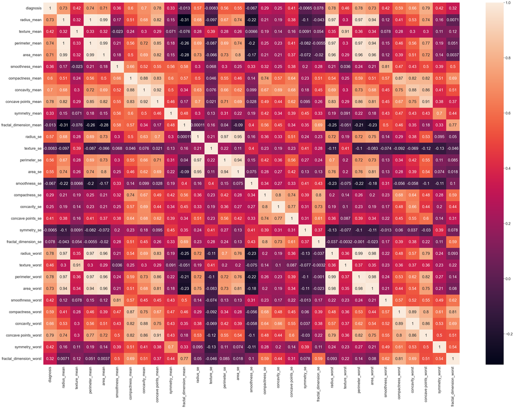

```python
# Pearson's Correlation Heatmap

plt.figure(figsize=(50,35))
sns.set(font_scale= 1.8)
plt.rcParams["axes.labelsize"] = 10
sns.heatmap(df.corr(), annot=True);
plt.show();
```

```python
# Data Cleaning
vars_to_remove = [
    # features that were highly correlated (greater than 0.95) were removed
    'perimeter_mean', 'area_mean', 'perimeter_worst', 'area_worst', 'radius_worst', 'radius_se'
]
df = df.drop(columns=vars_to_remove)
```

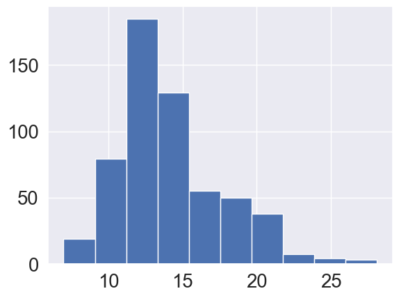

```python
# Creates a histogram using the values from the "radius_mean" column of the DataFrame
plt.hist(df["radius_mean"], color = 'b');
plt.show();
```

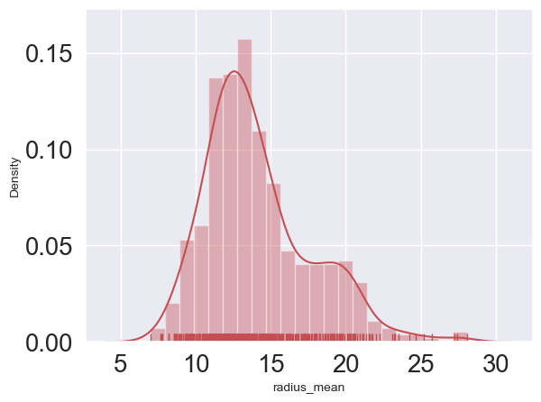

```python
# Creates a distribution plot of the "radius_mean" column from the DataFrame
sns.distplot(df["radius_mean"], color='r', rug=True);
plt.show();
```

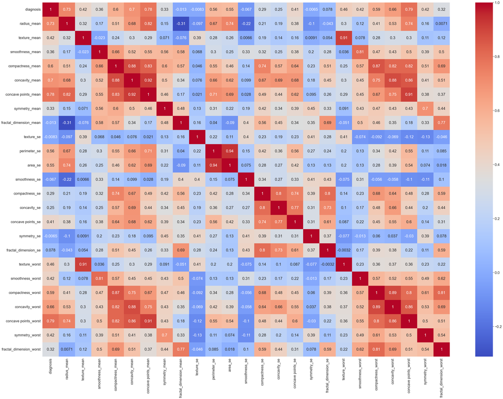

```python
# Pearson's Correlation Heatmap

plt.figure(figsize=(50,35))
sns.set(font_scale= 1.8)
plt.rcParams["axes.labelsize"] = 0.8
sns.heatmap(df.corr(), annot=True, cmap = "coolwarm");
plt.show();
```

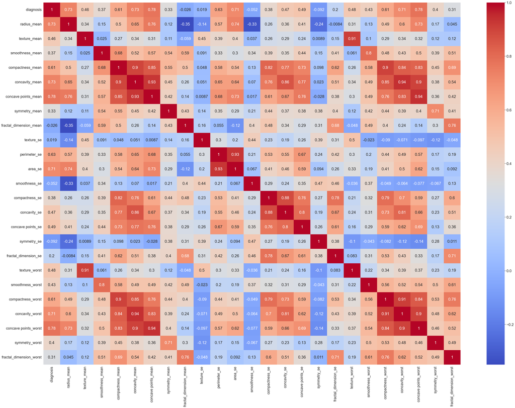

```python
# Spearman's Rank or Spearman's Rho correlation
plt.figure(figsize=(50,35))
sns.set(font_scale= 1.8)
plt.rcParams["axes.labelsize"] = 0.8
sns.heatmap(df.corr(method='spearman'), annot=True, cmap="coolwarm"); # nonparametric correlation
plt.show()
```

```python
# Phi K correlations for all variables
! pip install phik
import phik
from phik import resources, report
```

```python
df.phik_matrix()
```

```
interval columns not set, guessing: ['diagnosis', 'radius_mean', 'texture_mean', 'smoothness_mean', 'compactness_mean', 'concavity_mean', 'concave points_mean', 'symmetry_mean', 'fractal_dimension_mean', 'texture_se', 'perimeter_se', 'area_se', 'smoothness_se', 'compactness_se', 'concavity_se', 'con…
```

|  | diagnosis | radius_mean | texture_mean | smoothness_mean | compactness_mean | concavity_mean | concave points_mean | symmetry_mean | fractal_dimension_mean | texture_se | ... | concave points_se | symmetry_se | fractal_dimension_se | texture_worst | smoothness_worst | compactness_worst | concavity_worst | concave points_worst | symmetry_worst | fractal_dimension_worst |
| --- | --- | --- | --- | --- | --- | --- | --- | --- | --- | --- | --- | --- | --- | --- | --- | --- | --- | --- | --- | --- | --- |
| diagnosis | 1.00 | 0.93 | 0.61 | 0.47 | 0.78 | 0.92 | 0.96 | 0.43 | 0.21 | 0.10 | ... | 0.46 | 0.21 | 0.26 | 0.61 | 0.55 | 0.76 | 0.90 | 0.97 | 0.53 | 0.32 |
| radius_mean | 0.93 | 1.00 | 0.30 | 0.41 | 0.59 | 0.74 | 0.85 | 0.32 | 0.47 | 0.36 | ... | 0.35 | 0.36 | 0.21 | 0.30 | 0.23 | 0.52 | 0.61 | 0.76 | 0.16 | 0.19 |
| texture_mean | 0.61 | 0.30 | 1.00 | 0.00 | 0.32 | 0.40 | 0.36 | 0.16 | 0.00 | 0.36 | ... | 0.16 | 0.00 | 0.00 | 0.93 | 0.20 | 0.42 | 0.48 | 0.41 | 0.00 | 0.00 |
| smoothness_mean | 0.47 | 0.41 | 0.00 | 1.00 | 0.78 | 0.60 | 0.60 | 0.65 | 0.72 | 0.50 | ... | 0.37 | 0.44 | 0.34 | 0.00 | 0.82 | 0.53 | 0.46 | 0.53 | 0.68 | 0.57 |
| compactness_mean | 0.78 | 0.59 | 0.32 | 0.78 | 1.00 | 0.88 | 0.82 | 0.78 | 0.66 | 0.38 | ... | 0.59 | 0.69 | 0.48 | 0.18 | 0.67 | 0.86 | 0.86 | 0.83 | 0.73 | 0.62 |
| concavity_mean | 0.92 | 0.74 | 0.40 | 0.60 | 0.88 | 1.00 | 0.92 | 0.65 | 0.52 | 0.42 | ... | 0.63 | 0.45 | 0.53 | 0.36 | 0.50 | 0.76 | 0.86 | 0.84 | 0.53 | 0.45 |
| concave points_mean | 0.96 | 0.85 | 0.36 | 0.60 | 0.82 | 0.92 | 1.00 | 0.53 | 0.29 | 0.32 | ... | 0.57 | 0.28 | 0.26 | 0.35 | 0.47 | 0.69 | 0.77 | 0.90 | 0.50 | 0.34 |
| symmetry_mean | 0.43 | 0.32 | 0.16 | 0.65 | 0.78 | 0.65 | 0.53 | 1.00 | 0.59 | 0.45 | ... | 0.43 | 0.61 | 0.37 | 0.17 | 0.50 | 0.55 | 0.50 | 0.54 | 0.82 | 0.41 |
| fractal_dimension_mean | 0.21 | 0.47 | 0.00 | 0.72 | 0.66 | 0.52 | 0.29 | 0.59 | 1.00 | 0.15 | ... | 0.46 | 0.44 | 0.71 | 0.19 | 0.67 | 0.57 | 0.56 | 0.22 | 0.63 | 0.68 |
| texture_se | 0.10 | 0.36 | 0.36 | 0.50 | 0.38 | 0.42 | 0.32 | 0.45 | 0.15 | 1.00 | ... | 0.57 | 0.65 | 0.43 | 0.38 | 0.35 | 0.00 | 0.00 | 0.18 | 0.20 | 0.00 |
| perimeter_se | 0.58 | 0.71 | 0.27 | 0.30 | 0.54 | 0.67 | 0.71 | 0.39 | 0.20 | 0.34 | ... | 0.52 | 0.44 | 0.28 | 0.22 | 0.08 | 0.32 | 0.40 | 0.52 | 0.17 | 0.10 |
| area_se | 0.79 | 0.79 | 0.31 | 0.44 | 0.50 | 0.67 | 0.69 | 0.37 | 0.15 | 0.55 | ... | 0.43 | 0.38 | 0.20 | 0.33 | 0.09 | 0.29 | 0.40 | 0.52 | 0.13 | 0.00 |
| smoothness_se | 0.10 | 0.47 | 0.00 | 0.52 | 0.36 | 0.41 | 0.31 | 0.44 | 0.52 | 0.82 | ... | 0.69 | 0.69 | 0.58 | 0.00 | 0.53 | 0.00 | 0.00 | 0.19 | 0.00 | 0.17 |
| compactness_se | 0.34 | 0.28 | 0.19 | 0.41 | 0.64 | 0.65 | 0.45 | 0.44 | 0.55 | 0.55 | ... | 0.83 | 0.64 | 0.74 | 0.20 | 0.32 | 0.66 | 0.63 | 0.41 | 0.51 | 0.73 |
| concavity_se | 0.40 | 0.32 | 0.07 | 0.27 | 0.49 | 0.68 | 0.43 | 0.42 | 0.57 | 0.47 | ... | 0.85 | 0.44 | 0.81 | 0.00 | 0.07 | 0.37 | 0.69 | 0.34 | 0.29 | 0.40 |
| concave points_se | 0.46 | 0.35 | 0.16 | 0.37 | 0.59 | 0.63 | 0.57 | 0.43 | 0.46 | 0.57 | ... | 1.00 | 0.52 | 0.78 | 0.12 | 0.26 | 0.41 | 0.56 | 0.61 | 0.17 | 0.36 |
| symmetry_se | 0.21 | 0.36 | 0.00 | 0.44 | 0.69 | 0.45 | 0.28 | 0.61 | 0.44 | 0.65 | ... | 0.52 | 1.00 | 0.42 | 0.00 | 0.32 | 0.37 | 0.36 | 0.25 | 0.68 | 0.66 |
| fractal_dimension_se | 0.26 | 0.21 | 0.00 | 0.34 | 0.48 | 0.53 | 0.26 | 0.37 | 0.71 | 0.43 | ... | 0.78 | 0.42 | 1.00 | 0.04 | 0.27 | 0.39 | 0.46 | 0.20 | 0.16 | 0.53 |
| texture_worst | 0.61 | 0.30 | 0.93 | 0.00 | 0.18 | 0.36 | 0.35 | 0.17 | 0.19 | 0.38 | ... | 0.12 | 0.00 | 0.04 | 1.00 | 0.31 | 0.53 | 0.57 | 0.41 | 0.21 | 0.27 |
| smoothness_worst | 0.55 | 0.23 | 0.20 | 0.82 | 0.67 | 0.50 | 0.47 | 0.50 | 0.67 | 0.35 | ... | 0.26 | 0.32 | 0.27 | 0.31 | 1.00 | 0.69 | 0.57 | 0.59 | 0.69 | 0.63 |
| compactness_worst | 0.76 | 0.52 | 0.42 | 0.53 | 0.86 | 0.76 | 0.69 | 0.55 | 0.57 | 0.00 | ... | 0.41 | 0.37 | 0.39 | 0.53 | 0.69 | 1.00 | 0.93 | 0.79 | 0.75 | 0.80 |
| concavity_worst | 0.90 | 0.61 | 0.48 | 0.46 | 0.86 | 0.86 | 0.77 | 0.50 | 0.56 | 0.00 | ... | 0.56 | 0.36 | 0.46 | 0.57 | 0.57 | 0.93 | 1.00 | 0.83 | 0.66 | 0.74 |
| concave points_worst | 0.97 | 0.76 | 0.41 | 0.53 | 0.83 | 0.84 | 0.90 | 0.54 | 0.22 | 0.18 | ... | 0.61 | 0.25 | 0.20 | 0.41 | 0.59 | 0.79 | 0.83 | 1.00 | 0.53 | 0.41 |
| symmetry_worst | 0.53 | 0.16 | 0.00 | 0.68 | 0.73 | 0.53 | 0.50 | 0.82 | 0.63 | 0.20 | ... | 0.17 | 0.68 | 0.16 | 0.21 | 0.69 | 0.75 | 0.66 | 0.53 | 1.00 | 0.71 |
| fractal_dimension_worst | 0.32 | 0.19 | 0.00 | 0.57 | 0.62 | 0.45 | 0.34 | 0.41 | 0.68 | 0.00 | ... | 0.36 | 0.66 | 0.53 | 0.27 | 0.63 | 0.80 | 0.74 | 0.41 | 0.71 | 1.00 |

25 rows × 25 columns

```python
from phik.report import plot_correlation_matrix
phik_overview = df.phik_matrix()
```

```
interval columns not set, guessing: ['diagnosis', 'radius_mean', 'texture_mean', 'smoothness_mean', 'compactness_mean', 'concavity_mean', 'concave points_mean', 'symmetry_mean', 'fractal_dimension_mean', 'texture_se', 'perimeter_se', 'area_se', 'smoothness_se', 'compactness_se', 'concavity_se', 'con…
```

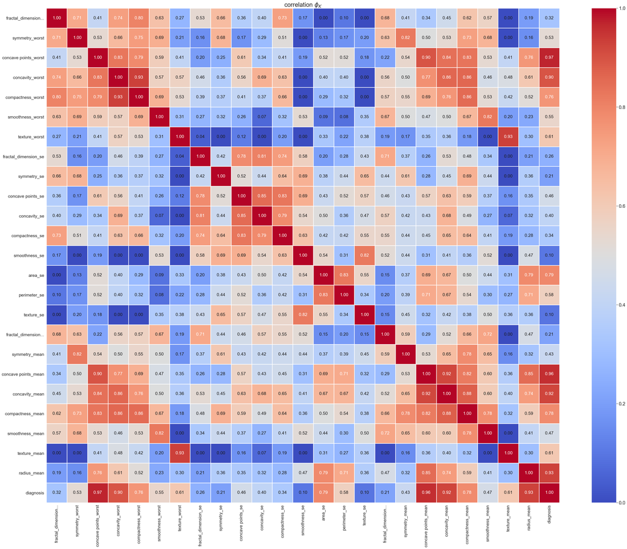

```python
# Presenting Phi K data as a heatmap (credit: Jai Gupta, Stanford SPCS 2023)
plot_correlation_matrix(phik_overview.values,
                        x_labels=phik_overview.columns,
                        y_labels=phik_overview.index,
                        vmin=0, vmax=1, color_map="coolwarm",
                        title=r"correlation $\phi_K$",
                        fontsize_factor=1.8,
                        figsize=(40, 32))
plt.tight_layout()
plt.show()
```

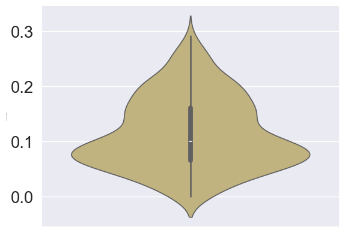

```python
# Creates a violin plot using the Seaborn library
sns.violinplot(df['concave points_worst'],color='y');
plt.show()
```

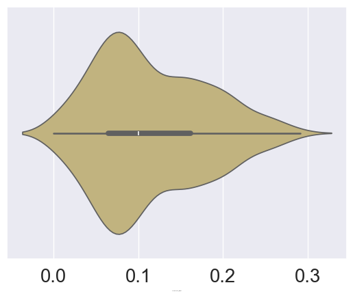

```python
sns.violinplot(x=df['concave points_worst'],color='y'); # Note inclusion of "x=" to rotate the plot
plt.show()
```

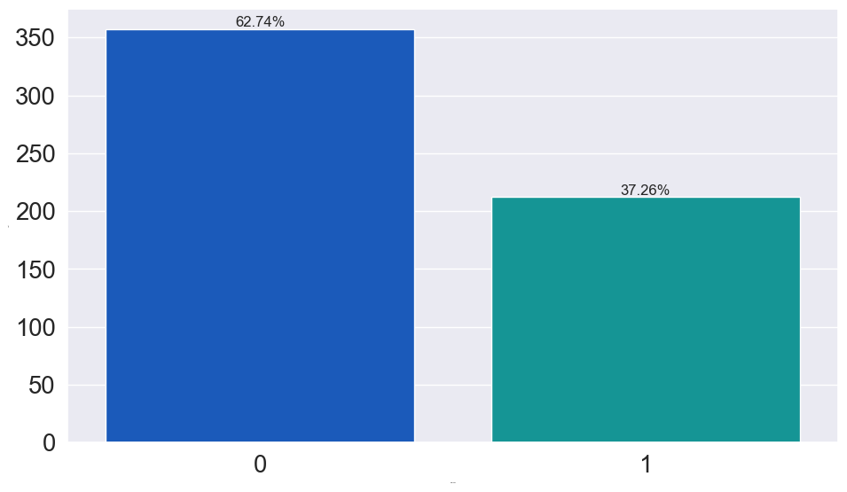

```python
# Function to create plot for categorical variable
# Annotate barplot
def annotate_bars(ax, feature):
    total = len(feature)
    for p in ax.patches:
        percentage = '{:.2f}%'.format(100 * p.get_height() / total)
        x = p.get_x() + p.get_width() / 2
        y = p.get_height()
        ax.annotate(percentage, (x, y), ha='center', va='bottom', size=12)

# Create figure and axis
fig, ax = plt.subplots(figsize=(10, 6))
sns.countplot(data=df, x='diagnosis', palette='winter', ax=ax)
annotate_bars(ax, df['diagnosis'])
plt.tight_layout()
plt.show()
```

```python
# From UT Austin Computer Science Department
# Used this function to create a combo boxplot and histogram for continuous (I/R --> int64 and float64) variables

def boxplot_histogram (feature, figsize=(10,7), bins = None):
    sns.set(font_scale=2)
    f2, (ax_box2, ax_hist2) = plt.subplots(nrows = 2,
                                           sharex = True,
                                           gridspec_kw = {"height_ratios": (.25, .75)},
                                           figsize = figsize
                                           )
    sns.boxplot(feature, ax=ax_box2, orient = "h", showmeans=True, color='red') # mean value will be noted
    sns.distplot(feature, kde=F, ax=ax_hist2, bins=bins) if bins else sns.distplot(feature, kde=False, ax=ax_hist2, fit=norm)
    ax_hist2.axvline(np.mean(feature), color='g', linestyle='--') # Add mean to the histogram
    ax_hist2.axvline(np.median(feature), color='black', linestyle='-') # Add median to the histogram
    plt.axvline(feature.mode()[0], color='r', linestyle='dashed', linewidth=1); #Add mode to the histogram
```

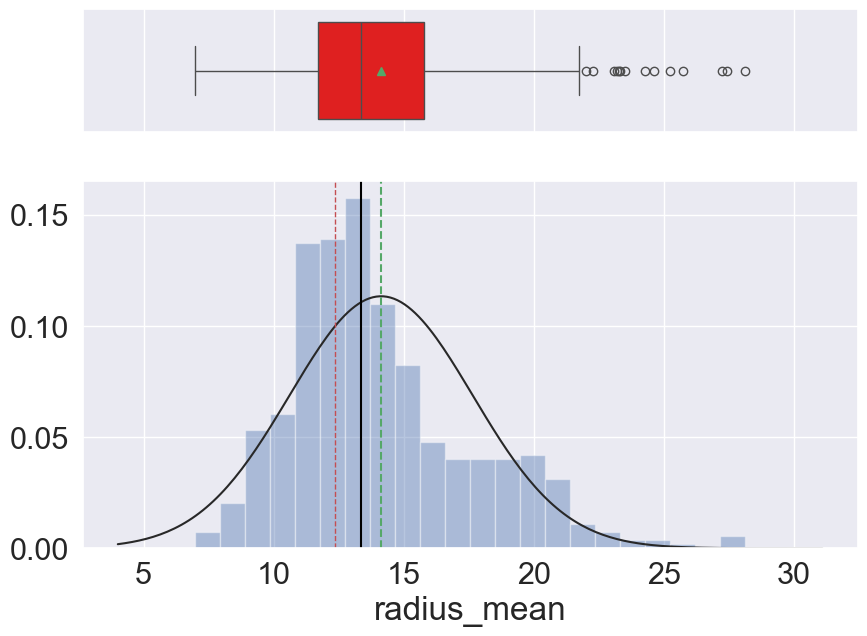

```python
boxplot_histogram(df.radius_mean)
plt.show()
```

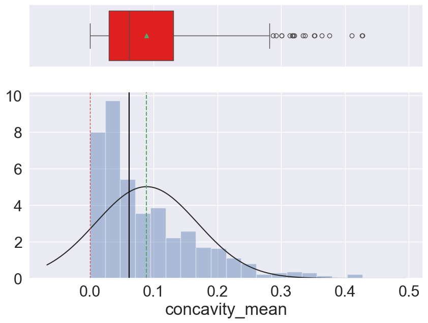

```python
boxplot_histogram(df.concavity_mean)
plt.show()
```

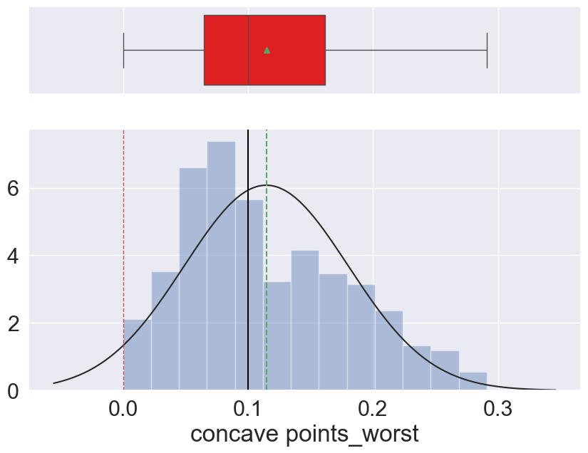

```python
boxplot_histogram(df["concave points_worst"])
plt.show()
```

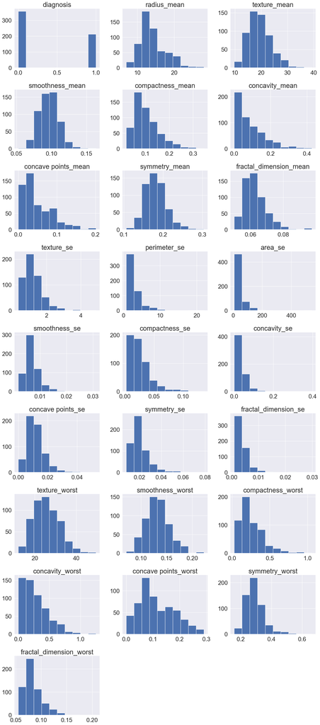

```python
# Plot histograms to check the distribution of each numeric variable
from scipy.stats import norm
all_col = df.select_dtypes(include=np.number).columns.tolist()
plt.figure(figsize=(17,75))

for i in range(len(all_col)):
    plt.subplot(18,3,i+1)
    plt.hist(df[all_col[i]])
    plt.tight_layout()
    plt.title(all_col[i],fontsize=25)

plt.show()
```

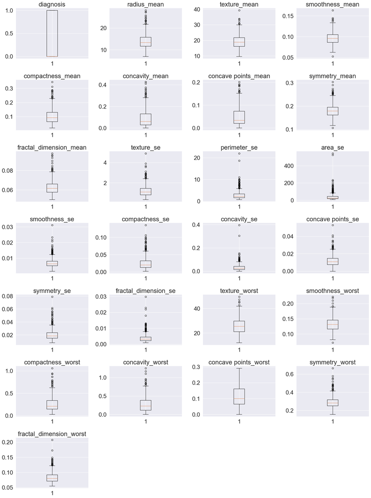

```python
# Outlier detection using boxplots (for all I/R variables)
plt.figure(figsize=(20,30))

for i, variable in enumerate(df): #enumerate is a built-in function in python that allows you to keep track of the number of iterations (loops) in a loop
                     plt.subplot(8,4,i+1) #provides a way to plot multiple plots on a single figure
                     plt.boxplot(df[variable],whis=1.5)
                     plt.tight_layout()
                     plt.title(variable)

plt.show()
```

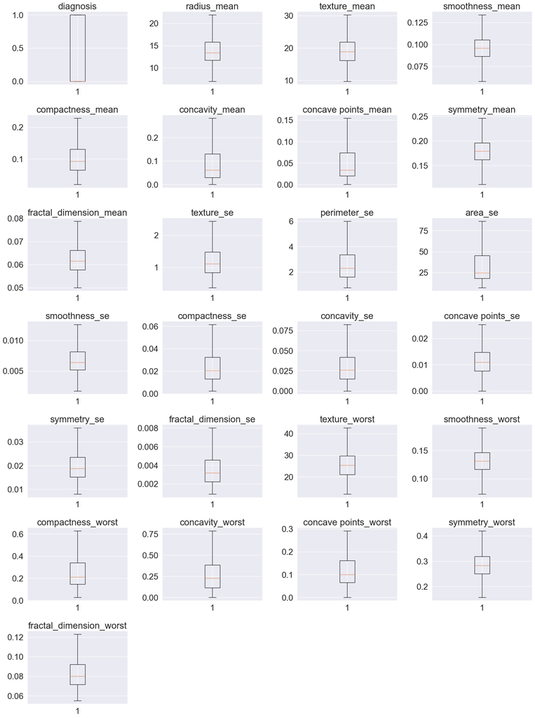

```python
# Use flooring and capping method
def treat_outliers(df,col):
    Q1=df[col].quantile(0.25)
    Q3=df[col].quantile(0.75)
    IQR=Q3-Q1
    Lower_Whisker = Q1 - 1.5*IQR
    Upper_Whisker = Q3 + 1.5*IQR
    df[col] = np.clip(df[col], Lower_Whisker, Upper_Whisker)
    return df

def treat_outliers_all(df, col_list):
    for c in col_list:
        df = treat_outliers(df,c)
    return df

numerical_col = df.select_dtypes(include=np.number).columns.tolist()
df = treat_outliers_all(df,numerical_col)

plt.figure(figsize=(20,30))

for i, variable in enumerate(numerical_col):
                     plt.subplot(8,4,i+1)
                     plt.boxplot(df[variable],whis=1.5)
                     plt.tight_layout()
                     plt.title(variable)

plt.show()
```

## Bivariate Analyses

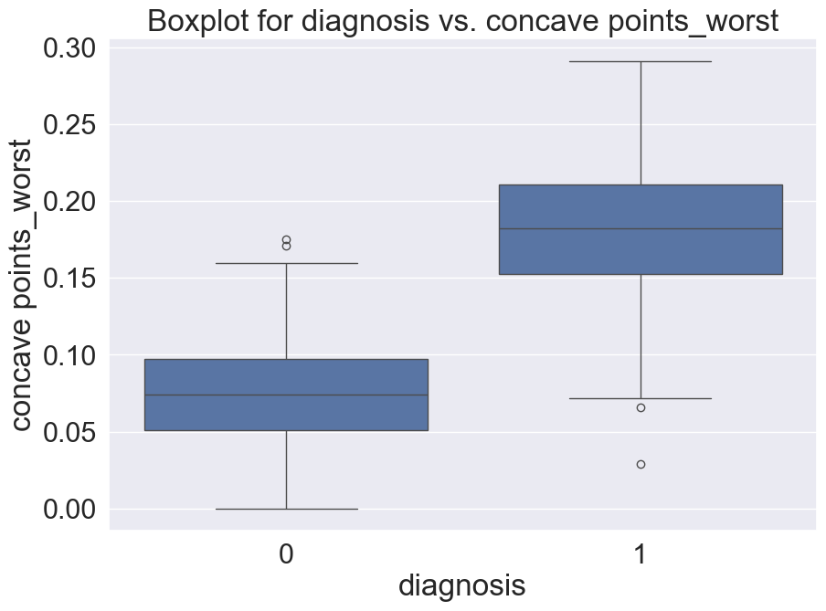

```python
# Boxplot with DV and 1 IV
# sns.boxplot(x = "categorical_var", y = "numeric_var", data = df)
# plt.title('graph_title')
# plt.show()

plt.figure(figsize=(10,7))
sns.boxplot(x = "diagnosis", y = "concave points_worst", data = df)
plt.title('Boxplot for diagnosis vs. concave points_worst')
plt.show()
```

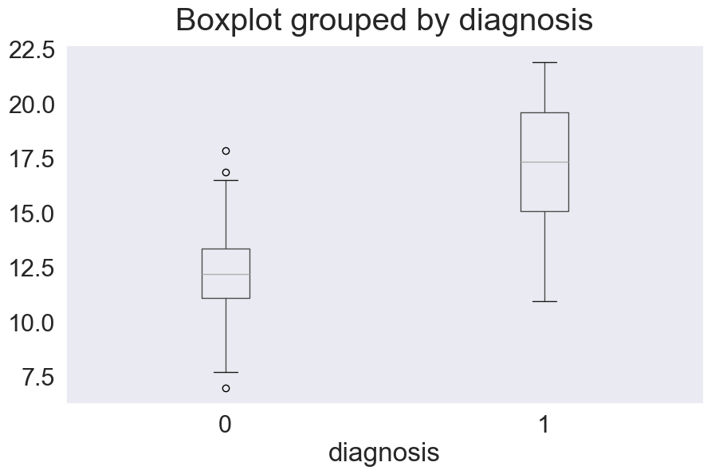

```python
ttest_boxplot = df.boxplot(column='radius_mean', by='diagnosis', figsize=(10, 6), grid=False);
ttest_boxplot.set_title('');
ttest_boxplot.set_ylabel('');
plt.show()
```

[figure not shown]

```python
# Catplot
sns.catplot(x="diagnosis", y="concave points_worst", data=df, kind='boxen', height=6, aspect=1.6, estimator=np.mean);
figsize=(10, 6)
plt.xlabel('diagnosis', fontsize=15);
plt.title('Catplot for concave points_mean vs. diagnosis')
plt.ylabel('concave points_mean', fontsize=15);
plt.show()
```

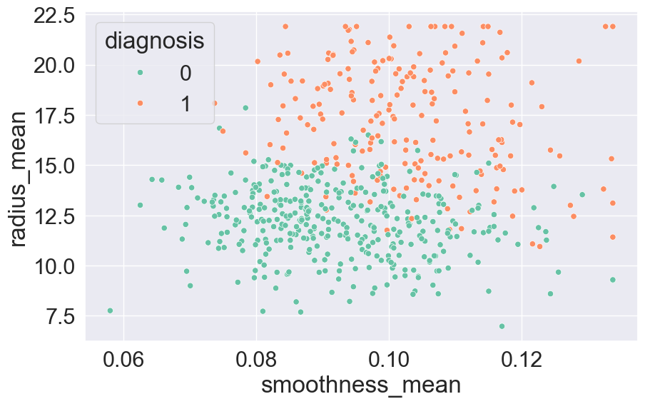

```python
plt.figure(figsize=(10,6))
sns.scatterplot(x='smoothness_mean', y='radius_mean', hue='diagnosis', data=df, palette='Set2')
plt.show()
```